# Bayesian Regression Models with RStanARM

TJ Mahr  
Sept. 21, 2016

Madison R Users Group

[Github repository](https://github.com/tjmahr/MadR_RStanARM)  
[@tjmahr](https://twitter.com/tjmahr)

### Overview

- [How I got into Bayesian statistics](http://rpubs.com/tjmahr/rep-crisis)
- [Some intuition-building about Bayes theorem](http://rpubs.com/tjmahr/bayes-theorem)
- [Tour of RStanARM](http://rpubs.com/tjmahr/rstanarm-tour)
- **[Where to learn more about Bayesian statistics](http://rpubs.com/tjmahr/bayes-learn-more)**

## Learning more

### You want to learn RStanARM

See the [vignettes](https://cran.rstudio.com/web/packages/rstanarm/). There is one for each kind of model.

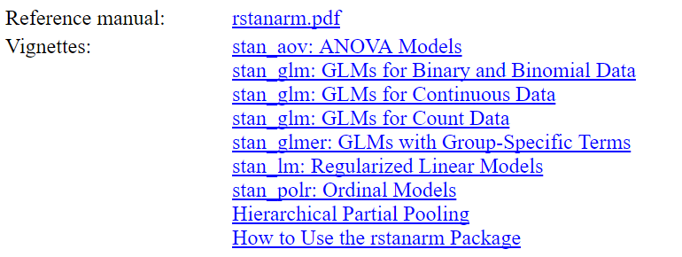

### You want to learn Stan

- Go to http://mc-stan.org/documentation/
- Look at the [example models](https://github.com/stan-dev/example-models/wiki) and read the manual.

### The Stan Manual

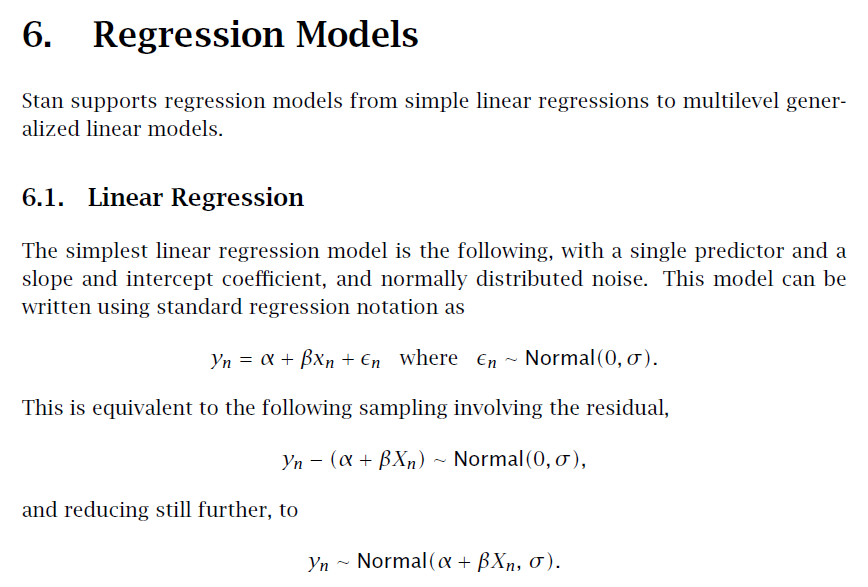

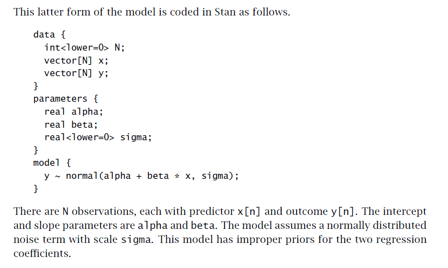

### You are trained in classical regression

Read [*Statistical Rethinking*](http://xcelab.net/rm/statistical-rethinking/) and [watch the lectures](https://www.youtube.com/playlist?list=PLDcUM9US4XdMdZOhJWJJD4mDBMnbTWw_z).

[figure not shown]

### 'Rethinking'

- This book is exceptional, stuffed to the brim with trivia, advice, and wisdom.
- Not just a book about statistics, but how we use statistical models in scientific practice.
- Explains side issues like MCMC, basics of information theory, or why the normal distribution is so prevalent – but just deep enough for the reader to get the intuitions needed for practice.
- My sole criticism is that its companion R `rethinking` package is not on CRAN.

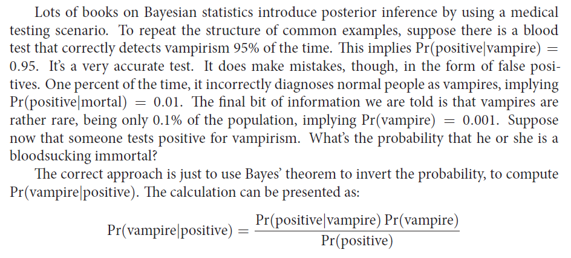

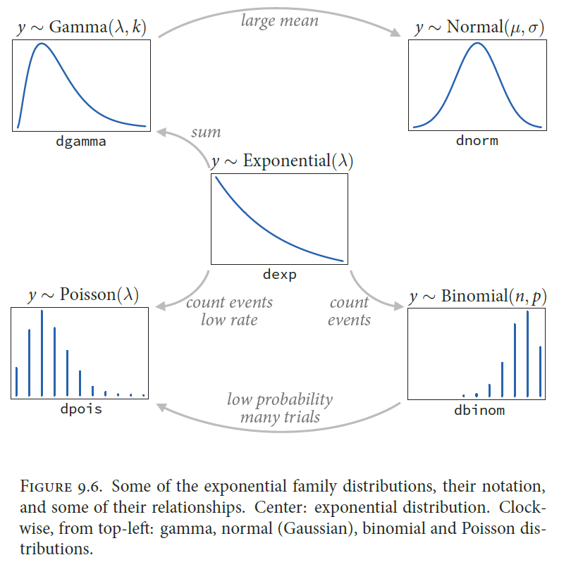

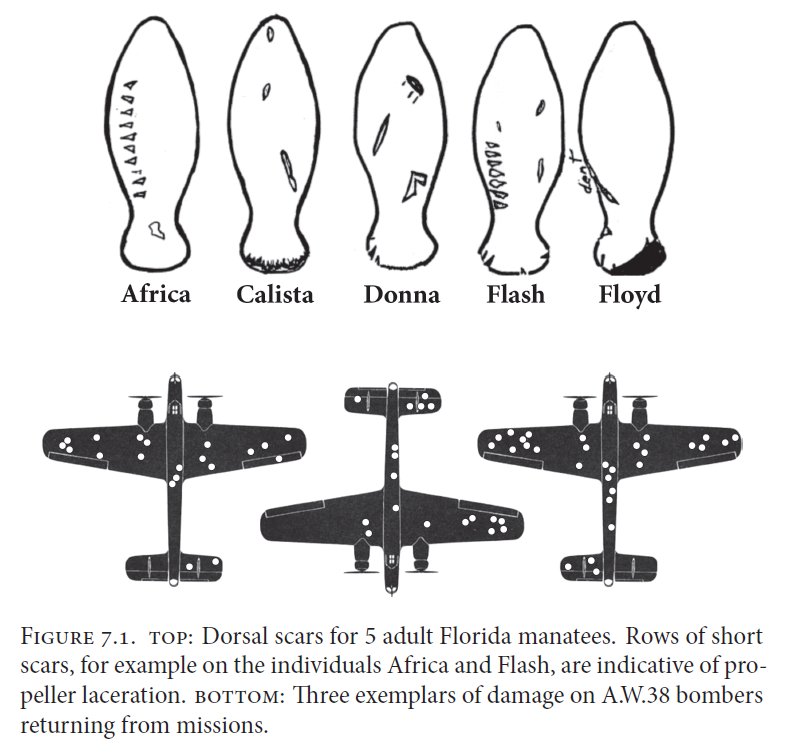

### You need puppies on the cover

I just got this book, but so far it's approachable and comprehensive, like a statistical cookbook. Many more equations and proofs than in *Rethinking*.

[figure not shown]

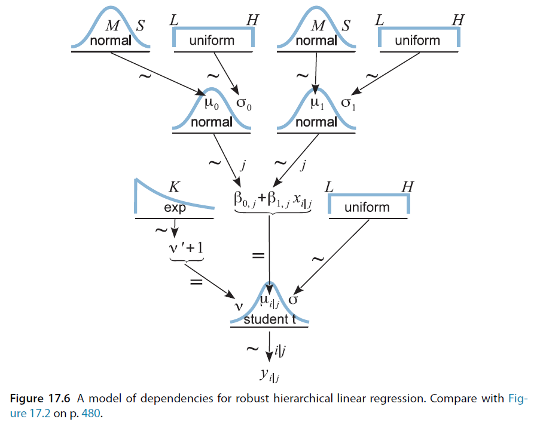

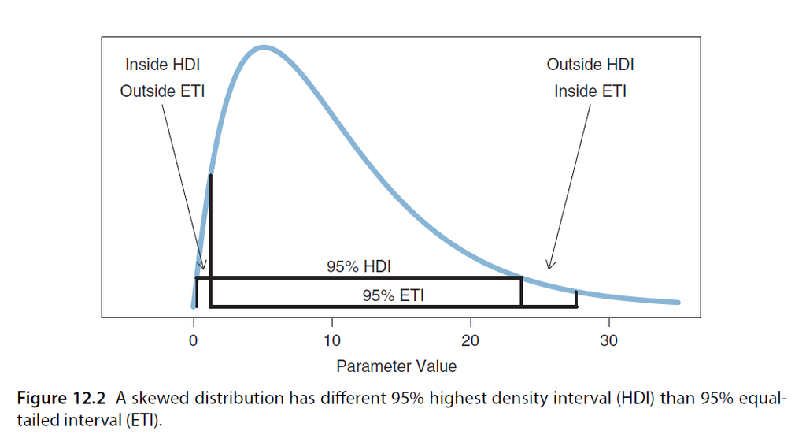

### You study psycholinguistics

- Nicenboim and Vasishth (2016). Statistical methods for linguistic research: Foundational Ideas - Part II. https://arxiv.org/abs/1602.00245
- Sorensen and Vasishth (2016). Bayesian linear mixed models using Stan: A tutorial for psychologists, linguists, and cognitive scientists. https://arxiv.org/abs/1506.06201

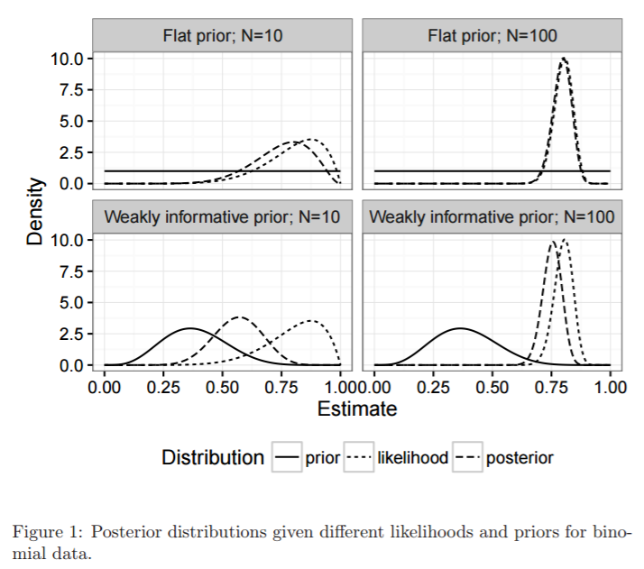

### You need a reading list and fast

- Etz, et al. (2016). [How to become a Bayesian in eight easy steps: An annotated reading list](https://www.researchgate.net/publication/301981861_How_to_become_a_Bayesian_in_eight_easy_steps_An_annotated_reading_list).
- Etz has also [great tutorials](https://alexanderetz.com/understanding-bayes/). They focus mostly on Bayes factors, a way to compare models using the denominators from Bayes theorem. *Statistical Rethinking* mentions these in passing in a single paragraph.